# MK Lecture) OMOP_SYNTHETIC library(RODBC) library(ggplot2) library(jsonlite) 180403

Please find the most updated version of this file in the following URL: https://github.com/mkim0710/tidystat/blob/master/Rmd/MK%20Lecture)%20OMOP_SYNTHETIC%20library(RODBC)%20library(ggplot2)%20library(jsonlite)%20180403.Rmd

Please “Fork” and send a “Pull request” if you have any suggestion on how to improve the codes.

Please find the acknowledgements section at the end of this document.

Thanks.

Min-hyung Kim

April 3, 2018

```r
# An appropriate ODBC driver should be installed in your computer first!
for (packagename in c("tidyverse", "RODBC", "maps", "jsonlite")) {
    if(!require(packagename, character.only = T)) install.packages(packagename)
}
detach("package:maps", unload=TRUE) # package:maps conflicts with some other packages, so load only when you need it, detach when you are done with it.
library(tidyverse)
library(RODBC)
# You should be within WCMC network to connect to VITS-ARCHSQLP04 server.
# If you are not not in WCMC network, you may have to set-up the MS SQL server, using the 1000 person data set in CDMv5 format provided by LTS Computing LLC. (If you set up some other database software, you may have to change the SQL codes because the syntax may be slightly different.)
# Or, you may just skip the library(RODBC) part and go to the library(jsonlite) part.
channel = odbcDriverConnect("Driver= {SQL Server}; server=VITS-ARCHSQLP04; database=OMOP_SYNTHETIC")
```

```r
sqlQuery(channel, "
select distinct TABLE_NAME
from information_schema.columns
;")
```

|  | TABLE_NAME |
| --- | --- |
| 1 | CARE_SITE |
| 2 | CDM_DRUG_EXPOSURE |
| 3 | CONCEPT |
| 4 | CONCEPT_ANCESTOR |
| 5 | CONCEPT_CLASS |
| 6 | CONCEPT_RELATIONSHIP |
| 7 | CONCEPT_SYNONYM |
| 8 | CONDITION_ERA |
| 9 | CONDITION_OCCURRENCE |
| 10 | DEATH |

[output cut: 12 more lines]

```r
sqlQuery(channel, "
SELECT TABLE_NAME, COLUMN_NAME, IS_NULLABLE, DATA_TYPE
FROM information_schema.columns
WHERE TABLE_NAME in ('PERSON', 'VISIT_OCCURRENCE', 'CONDITION_OCCURRENCE', 'LOCATION')
;")
```

|  | TABLE_NAME | COLUMN_NAME | IS_NULLABLE | DATA_TYPE |
| --- | --- | --- | --- | --- |
| 1 | CONDITION_OCCURRENCE | CONDITION_OCCURRENCE_ID | YES | varchar |
| 2 | CONDITION_OCCURRENCE | PERSON_ID | YES | varchar |
| 3 | CONDITION_OCCURRENCE | CONDITION_CONCEPT_ID | YES | varchar |
| 4 | CONDITION_OCCURRENCE | CONDITION_START_DATE | YES | varchar |
| 5 | CONDITION_OCCURRENCE | CONDITION_END_DATE | YES | varchar |
| 6 | CONDITION_OCCURRENCE | CONDITION_TYPE_CONCEPT_ID | YES | varchar |
| 7 | CONDITION_OCCURRENCE | STOP_REASON | YES | varchar |
| 8 | CONDITION_OCCURRENCE | PROVIDER_ID | YES | varchar |
| 9 | CONDITION_OCCURRENCE | VISIT_OCCURRENCE_ID | YES | varchar |
| 10 | CONDITION_OCCURRENCE | CONDITION_SOURCE_VALUE | YES | varchar |

[output cut: 39 more lines]

```r
sqlQuery(channel, "
SELECT *
FROM INFORMATION_SCHEMA.KEY_COLUMN_USAGE
;")
```

| CONSTRAINT_CATALOG | CONSTRAINT_SCHEMA | CONSTRAINT_NAME | TABLE_CATALOG | TABLE_SCHEMA | TABLE_NAME | COLUMN_NAME | ORDINAL_POSITION |
| --- | --- | --- | --- | --- | --- | --- | --- |

```r
sqlQuery(channel, "
select count(*) as nrow
    , count(distinct CONDITION_OCCURRENCE_ID) as n_distinct_CONDITION_OCCURRENCE_ID
    , count(distinct CONDITION_OCCURRENCE.VISIT_OCCURRENCE_ID) as n_distinct_VISIT_OCCURRENCE_ID
    , count(distinct CONDITION_OCCURRENCE.PERSON_ID) as n_distinct_PERSON_ID
from CONDITION_OCCURRENCE
;")
```

|  | nrow | n_distinct_CONDITION_OCCURRENCE_ID | n_distinct_VISIT_OCCURRENCE_ID | n_distinct_PERSON_ID |
| --- | --- | --- | --- | --- |
| 1 | 160322 | 160322 | 44526 | 836 |

```r
varnames = sqlQuery(channel, "
SELECT COLUMN_NAME
FROM information_schema.columns
WHERE TABLE_NAME = 'VISIT_OCCURRENCE'
;")[[1]]
qryText = paste0(
    "select count(*) as nrow"
    , paste0(
        ", count(distinct "
        , varnames
        , ") as n_distinct_"
        , varnames
        , collapse = ""
    )
    , " from VISIT_OCCURRENCE;"
)
qryText
```

```
[1] "select count(*) as nrow, count(distinct VISIT_OCCURRENCE_ID) as n_distinct_VISIT_OCCURRENCE_ID, count(distinct PERSON_ID) as n_distinct_PERSON_ID, count(distinct VISIT_CONCEPT_ID) as n_distinct_VISIT_CONCEPT_ID, count(distinct VISIT_START_DATE) as n_distinct_VISIT_START_DATE, count(distinct VIS…
```

```r
sqlQuery(channel, qryText) %>% t
```

```
                                       1
nrow                               47457
n_distinct_VISIT_OCCURRENCE_ID     47457
n_distinct_PERSON_ID                 842
n_distinct_VISIT_CONCEPT_ID            3
n_distinct_VISIT_START_DATE         1096
n_distinct_VISIT_START_TIME            1
n_distinct_VISIT_END_DATE           1096
n_distinct_VISIT_END_TIME              1
n_distinct_VISIT_TYPE_CONCEPT_ID       1
n_distinct_PROVIDER_ID             34140
n_distinct_CARE_SITE_ID            20713
n_distinct_VISIT_SOURCE_VALUE      47457
n_distinct_VISIT_SOURCE_CONCEPT_ID     1
```

```r
VISIT_OCCURRENCE = sqlQuery(channel, "
select *
from VISIT_OCCURRENCE
;")
VISIT_OCCURRENCE %>% summarise_all(n_distinct) %>% t
```

```
                         [,1]
VISIT_OCCURRENCE_ID     47457
PERSON_ID                 842
VISIT_CONCEPT_ID            3
VISIT_START_DATE         1096
VISIT_START_TIME            1
VISIT_END_DATE           1096
VISIT_END_TIME              1
VISIT_TYPE_CONCEPT_ID       1
PROVIDER_ID             34140
CARE_SITE_ID            20713
VISIT_SOURCE_VALUE      47457
VISIT_SOURCE_CONCEPT_ID     1
```

```r
sqlQuery(channel, paste("
select CONDITION_CONCEPT_ID, CONDITION_SOURCE_VALUE, count(*) as nrow, count(distinct CONDITION_OCCURRENCE_ID) as CONDITION_OCCURRENCE_ID_n_distinct, count(distinct PERSON_ID) as PERSON_ID_n_distinct
from CONDITION_OCCURRENCE
where (CONDITION_SOURCE_VALUE like '2962%'
    or CONDITION_SOURCE_VALUE like '2963%'
)
group by CONDITION_CONCEPT_ID, CONDITION_SOURCE_VALUE
order by CONDITION_SOURCE_VALUE
;"))
```

|  | CONDITION_CONCEPT_ID | CONDITION_SOURCE_VALUE | nrow | CONDITION_OCCURRENCE_ID_n_distinct | PERSON_ID_n_distinct |
| --- | --- | --- | --- | --- | --- |
| 1 | 432284 | 29620 | 51 | 51 | 35 |
| 2 | 436945 | 29621 | 14 | 14 | 12 |
| 3 | 437837 | 29622 | 27 | 27 | 24 |
| 4 | 441534 | 29623 | 25 | 25 | 18 |
| 5 | 438406 | 29624 | 10 | 10 | 9 |
| 6 | 432284 | 29625 | 13 | 13 | 13 |
| 7 | 433750 | 29626 | 7 | 7 | 7 |
| 8 | 432285 | 29630 | 60 | 60 | 41 |
| 9 | 438998 | 29631 | 27 | 27 | 24 |
| 10 | 432883 | 29632 | 85 | 85 | 48 |

[output cut: 4 more lines]

```r
sqlQuery(channel, paste("
select PERSON_ID, count(*) as nrow, count(distinct CONDITION_OCCURRENCE_ID) as n_distinct_CONDITION_OCCURRENCE_ID, count(distinct PERSON_ID) as n_distinct_PERSON_ID, count(distinct CONDITION_SOURCE_VALUE) as n_distinct_CONDITION_SOURCE_VALUE
from CONDITION_OCCURRENCE
where (CONDITION_SOURCE_VALUE like '2962%'
    or CONDITION_SOURCE_VALUE like '2963%'
)
group by PERSON_ID
order by count(distinct CONDITION_SOURCE_VALUE) desc
;"))
```

|  | PERSON_ID | nrow | n_distinct_CONDITION_OCCURRENCE_ID | n_distinct_PERSON_ID | n_distinct_CONDITION_SOURCE_VALUE |
| --- | --- | --- | --- | --- | --- |
| 1 | 258 | 17 | 17 | 1 | 9 |
| 2 | 144 | 11 | 11 | 1 | 6 |
| 3 | 132 | 8 | 8 | 1 | 6 |
| 4 | 167 | 33 | 33 | 1 | 6 |
| 5 | 768 | 9 | 9 | 1 | 6 |
| 6 | 1097 | 9 | 9 | 1 | 5 |
| 7 | 1076 | 14 | 14 | 1 | 5 |
| 8 | 758 | 5 | 5 | 1 | 5 |
| 9 | 762 | 4 | 4 | 1 | 4 |
| 10 | 598 | 6 | 6 | 1 | 4 |

[output cut: 174 more lines]

```r
sqlQuery(channel, paste("
select CONDITION_OCCURRENCE_ID, VISIT_OCCURRENCE_ID, PERSON_ID, CONDITION_SOURCE_VALUE, CONDITION_START_DATE, CONDITION_END_DATE
from CONDITION_OCCURRENCE
where (CONDITION_SOURCE_VALUE like '2962%'
    or CONDITION_SOURCE_VALUE like '2963%'
) and PERSON_ID = 258
order by CONDITION_START_DATE
;"))
```

|  | CONDITION_OCCURRENCE_ID | VISIT_OCCURRENCE_ID | PERSON_ID | CONDITION_SOURCE_VALUE | CONDITION_START_DATE | CONDITION_END_DATE |
| --- | --- | --- | --- | --- | --- | --- |
| 1 | 290742 | 107945 | 258 | 29623 | 20080126 | 20080126 |
| 2 | 254192 | 86392 | 258 | 29624 | 20080223 | 20080223 |
| 3 | 8500 | 86392 | 258 | 29631 | 20080223 | 20080223 |
| 4 | 563561 | 13095 | 258 | 29625 | 20080601 | 20080601 |
| 5 | 102598 | 13095 | 258 | 29632 | 20080601 | 20080601 |
| 6 | 21670 | 78816 | 258 | 29634 | 20080607 | 20080607 |
| 7 | 113158 | 99707 | 258 | 29632 | 20080817 | 20080817 |
| 8 | 249392 | 80973 | 258 | 29624 | 20081006 | 20081006 |
| 9 | 31750 | 18870 | 258 | 29634 | 20090206 | 20090206 |
| 10 | 21883 | 17434 | 258 | 29633 | 20090405 | 20090414 |

[output cut: 7 more lines]

```r
#@ total & MDD & pMDD (PERSON_ID_n_distinct, 1-year period prevalence/proportion) ------
tblTotal = sqlQuery(channel, paste("
select year(convert(datetime, CONDITION_START_DATE, 112)) as CONDITION_START_year
    , GENDER_SOURCE_VALUE
    , count(*) as nrow
    , count(distinct CONDITION_OCCURRENCE_ID) as n_distinct_CONDITION_OCCURRENCE_ID
    , count(distinct CONDITION_OCCURRENCE.VISIT_OCCURRENCE_ID) as n_distinct_VISIT_OCCURRENCE_ID
    , count(distinct CONDITION_OCCURRENCE.PERSON_ID) as n_distinct_PERSON_ID
from (
    CONDITION_OCCURRENCE
    left join VISIT_OCCURRENCE
    on CONDITION_OCCURRENCE.VISIT_OCCURRENCE_ID = VISIT_OCCURRENCE.VISIT_OCCURRENCE_ID
    left join PERSON
    on VISIT_OCCURRENCE.PERSON_ID = PERSON.PERSON_ID
)
group by year(convert(datetime, CONDITION_START_DATE, 112)), GENDER_SOURCE_VALUE
order by year(convert(datetime, CONDITION_START_DATE, 112)), GENDER_SOURCE_VALUE
;"))
tblTotal
```

|  | CONDITION_START_year | GENDER_SOURCE_VALUE | nrow | n_distinct_CONDITION_OCCURRENCE_ID | n_distinct_VISIT_OCCURRENCE_ID | n_distinct_PERSON_ID |
| --- | --- | --- | --- | --- | --- | --- |
| 1 | 2008 | Female | 30327 | 30327 | 8439 | 375 |
| 2 | 2008 | Male | 27379 | 27379 | 7667 | 346 |
| 3 | 2009 | Female | 31871 | 31871 | 8917 | 404 |
| 4 | 2009 | Male | 31302 | 31302 | 8703 | 387 |
| 5 | 2010 | Female | 20231 | 20231 | 5509 | 390 |
| 6 | 2010 | Male | 19212 | 19212 | 5291 | 369 |

```r
tblMDD = sqlQuery(channel, paste("
select year(convert(datetime, CONDITION_START_DATE, 112)) as CONDITION_START_year
    , GENDER_SOURCE_VALUE
    , count(*) as nrow
    , count(distinct CONDITION_OCCURRENCE_ID) as n_distinct_CONDITION_OCCURRENCE_ID
    , count(distinct CONDITION_OCCURRENCE.VISIT_OCCURRENCE_ID) as n_distinct_VISIT_OCCURRENCE_ID
    , count(distinct CONDITION_OCCURRENCE.PERSON_ID) as n_distinct_PERSON_ID
from (
    CONDITION_OCCURRENCE
    left join VISIT_OCCURRENCE
    on CONDITION_OCCURRENCE.VISIT_OCCURRENCE_ID = VISIT_OCCURRENCE.VISIT_OCCURRENCE_ID
    left join PERSON
    on VISIT_OCCURRENCE.PERSON_ID = PERSON.PERSON_ID
)
where (CONDITION_SOURCE_VALUE like '2962%'
    or CONDITION_SOURCE_VALUE like '2963%'
)
group by year(convert(datetime, CONDITION_START_DATE, 112)), GENDER_SOURCE_VALUE
order by year(convert(datetime, CONDITION_START_DATE, 112)), GENDER_SOURCE_VALUE
;"))
tblMDD = full_join(select(tblTotal, -nrow, -n_distinct_CONDITION_OCCURRENCE_ID, -n_distinct_VISIT_OCCURRENCE_ID, -n_distinct_PERSON_ID), tblMDD)
tblMDD
```

| CONDITION_START_year | GENDER_SOURCE_VALUE | nrow | n_distinct_CONDITION_OCCURRENCE_ID | n_distinct_VISIT_OCCURRENCE_ID | n_distinct_PERSON_ID |
| --- | --- | --- | --- | --- | --- |
| 2008 | Female | 90 | 90 | 65 | 42 |
| 2008 | Male | 100 | 100 | 56 | 41 |
| 2009 | Female | 103 | 103 | 68 | 48 |
| 2009 | Male | 132 | 132 | 75 | 48 |
| 2010 | Female | 56 | 56 | 34 | 29 |
| 2010 | Male | 49 | 49 | 35 | 32 |

```r
tblMDDp = tblMDD; tblMDDp[,c("nrow", "n_distinct_CONDITION_OCCURRENCE_ID", "n_distinct_VISIT_OCCURRENCE_ID", "n_distinct_PERSON_ID")] = tblMDD[,c("nrow", "n_distinct_CONDITION_OCCURRENCE_ID", "n_distinct_VISIT_OCCURRENCE_ID", "n_distinct_PERSON_ID")]/tblTotal[,c("nrow", "n_distinct_CONDITION_OCCURRENCE_ID", "n_distinct_VISIT_OCCURRENCE_ID", "n_distinct_PERSON_ID")]
tblMDDp
```

| CONDITION_START_year | GENDER_SOURCE_VALUE | nrow | n_distinct_CONDITION_OCCURRENCE_ID | n_distinct_VISIT_OCCURRENCE_ID | n_distinct_PERSON_ID |
| --- | --- | --- | --- | --- | --- |
| 2008 | Female | 0.002967653 | 0.002967653 | 0.007702334 | 0.11200000 |
| 2008 | Male | 0.003652434 | 0.003652434 | 0.007304030 | 0.11849711 |
| 2009 | Female | 0.003231778 | 0.003231778 | 0.007625883 | 0.11881188 |
| 2009 | Male | 0.004216983 | 0.004216983 | 0.008617718 | 0.12403101 |
| 2010 | Female | 0.002768029 | 0.002768029 | 0.006171719 | 0.07435897 |
| 2010 | Male | 0.002550489 | 0.002550489 | 0.006615007 | 0.08672087 |

```r
g = tblMDDp %>% ggplot(aes(x = as.factor(CONDITION_START_year), y = n_distinct_PERSON_ID, group = GENDER_SOURCE_VALUE, color = GENDER_SOURCE_VALUE, fill = GENDER_SOURCE_VALUE))
```

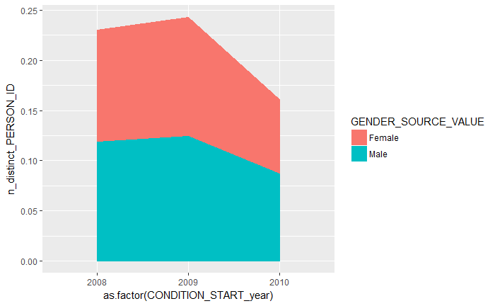

```r
g+geom_area(position = "stack")
```

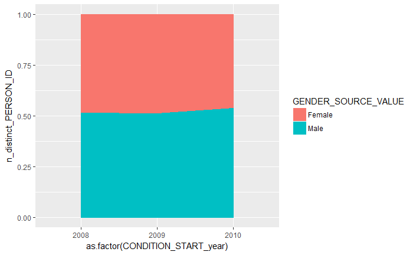

```r
g+geom_area(position = "fill")
```

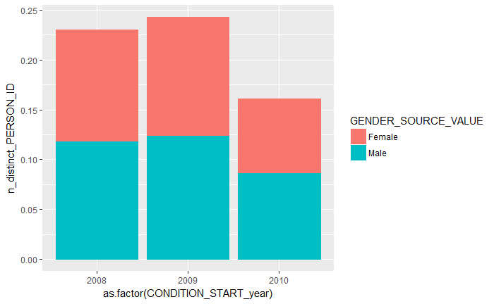

```r
g+geom_col(position = "stack")
```

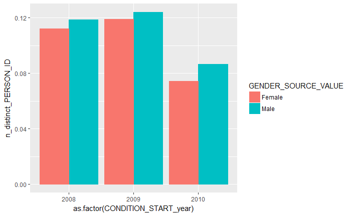

```r
g+geom_col(position = "dodge")
```

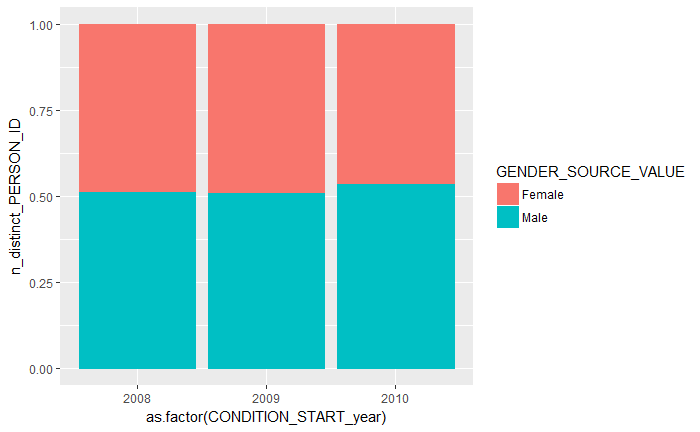

```r
g+geom_col(position = "fill")
```

```r
#@ total & MDD & pMDD (n_distinct_PERSON_ID, 1-month period prevalence/proportion) ------
tblTotal = sqlQuery(channel, paste("
select year(convert(datetime, CONDITION_START_DATE, 112)) as CONDITION_START_year
    , month(convert(datetime, CONDITION_START_DATE, 112)) as CONDITION_START_month
    , GENDER_SOURCE_VALUE
    , count(*) as nrow
    , count(distinct CONDITION_OCCURRENCE_ID) as n_distinct_CONDITION_OCCURRENCE_ID
    , count(distinct CONDITION_OCCURRENCE.VISIT_OCCURRENCE_ID) as n_distinct_VISIT_OCCURRENCE_ID
    , count(distinct CONDITION_OCCURRENCE.PERSON_ID) as n_distinct_PERSON_ID
from (
    CONDITION_OCCURRENCE
    left join VISIT_OCCURRENCE
    on CONDITION_OCCURRENCE.VISIT_OCCURRENCE_ID = VISIT_OCCURRENCE.VISIT_OCCURRENCE_ID
    left join PERSON
    on VISIT_OCCURRENCE.PERSON_ID = PERSON.PERSON_ID
)
group by year(convert(datetime, CONDITION_START_DATE, 112)), month(convert(datetime, CONDITION_START_DATE, 112)), GENDER_SOURCE_VALUE
order by year(convert(datetime, CONDITION_START_DATE, 112)), month(convert(datetime, CONDITION_START_DATE, 112)), GENDER_SOURCE_VALUE
;"))
tblTotal
```

|  | CONDITION_START_year | CONDITION_START_month | GENDER_SOURCE_VALUE | nrow | n_distinct_CONDITION_OCCURRENCE_ID | n_distinct_VISIT_OCCURRENCE_ID | n_distinct_PERSON_ID |
| --- | --- | --- | --- | --- | --- | --- | --- |
| 1 | 2008 | 1 | Female | 1335 | 1335 | 354 | 159 |
| 2 | 2008 | 1 | Male | 1059 | 1059 | 288 | 116 |
| 3 | 2008 | 2 | Female | 1896 | 1896 | 532 | 208 |
| 4 | 2008 | 2 | Male | 1621 | 1621 | 448 | 172 |
| 5 | 2008 | 3 | Female | 2544 | 2544 | 681 | 257 |
| 6 | 2008 | 3 | Male | 2245 | 2245 | 601 | 218 |
| 7 | 2008 | 4 | Female | 2674 | 2674 | 747 | 272 |
| 8 | 2008 | 4 | Male | 2256 | 2256 | 641 | 233 |
| 9 | 2008 | 5 | Female | 2765 | 2765 | 766 | 276 |
| 10 | 2008 | 5 | Male | 2332 | 2332 | 657 | 242 |

[output cut: 62 more lines]

```r
tblMDD = sqlQuery(channel, paste("
select year(convert(datetime, CONDITION_START_DATE, 112)) as CONDITION_START_year
    , month(convert(datetime, CONDITION_START_DATE, 112)) as CONDITION_START_month
    , GENDER_SOURCE_VALUE
    , count(*) as nrow
    , count(distinct CONDITION_OCCURRENCE_ID) as n_distinct_CONDITION_OCCURRENCE_ID
    , count(distinct CONDITION_OCCURRENCE.VISIT_OCCURRENCE_ID) as n_distinct_VISIT_OCCURRENCE_ID
    , count(distinct CONDITION_OCCURRENCE.PERSON_ID) as n_distinct_PERSON_ID
from (
    CONDITION_OCCURRENCE
    left join VISIT_OCCURRENCE
    on CONDITION_OCCURRENCE.VISIT_OCCURRENCE_ID = VISIT_OCCURRENCE.VISIT_OCCURRENCE_ID
    left join PERSON
    on VISIT_OCCURRENCE.PERSON_ID = PERSON.PERSON_ID
)
where (CONDITION_SOURCE_VALUE like '2962%'
    or CONDITION_SOURCE_VALUE like '2963%'
)
group by year(convert(datetime, CONDITION_START_DATE, 112)), month(convert(datetime, CONDITION_START_DATE, 112)), GENDER_SOURCE_VALUE
order by year(convert(datetime, CONDITION_START_DATE, 112)), month(convert(datetime, CONDITION_START_DATE, 112)), GENDER_SOURCE_VALUE
;"))
tblMDD = full_join(select(tblTotal, -nrow, -n_distinct_CONDITION_OCCURRENCE_ID, -n_distinct_VISIT_OCCURRENCE_ID, -n_distinct_PERSON_ID), tblMDD)
tblMDD
```

| CONDITION_START_year | CONDITION_START_month | GENDER_SOURCE_VALUE | nrow | n_distinct_CONDITION_OCCURRENCE_ID | n_distinct_VISIT_OCCURRENCE_ID | n_distinct_PERSON_ID |
| --- | --- | --- | --- | --- | --- | --- |
| 2008 | 1 | Female | 4 | 4 | 4 | 4 |
| 2008 | 1 | Male | 4 | 4 | 2 | 2 |
| 2008 | 2 | Female | 14 | 14 | 7 | 6 |
| 2008 | 2 | Male | 15 | 15 | 5 | 4 |
| 2008 | 3 | Female | 5 | 5 | 5 | 5 |
| 2008 | 3 | Male | 7 | 7 | 5 | 5 |
| 2008 | 4 | Female | 5 | 5 | 5 | 5 |
| 2008 | 4 | Male | 3 | 3 | 3 | 3 |
| 2008 | 5 | Female | 9 | 9 | 7 | 6 |
| 2008 | 5 | Male | 3 | 3 | 2 | 2 |

[output cut: 62 more lines]

```r
tblMDDp = tblMDD; tblMDDp[,c("nrow", "n_distinct_CONDITION_OCCURRENCE_ID", "n_distinct_VISIT_OCCURRENCE_ID", "n_distinct_PERSON_ID")] = tblMDD[,c("nrow", "n_distinct_CONDITION_OCCURRENCE_ID", "n_distinct_VISIT_OCCURRENCE_ID", "n_distinct_PERSON_ID")]/tblTotal[,c("nrow", "n_distinct_CONDITION_OCCURRENCE_ID", "n_distinct_VISIT_OCCURRENCE_ID", "n_distinct_PERSON_ID")]
tblMDDp
```

| CONDITION_START_year | CONDITION_START_month | GENDER_SOURCE_VALUE | nrow | n_distinct_CONDITION_OCCURRENCE_ID | n_distinct_VISIT_OCCURRENCE_ID | n_distinct_PERSON_ID |
| --- | --- | --- | --- | --- | --- | --- |
| 2008 | 1 | Female | 0.0029962547 | 0.0029962547 | 0.011299435 | 0.025157233 |
| 2008 | 1 | Male | 0.0037771483 | 0.0037771483 | 0.006944444 | 0.017241379 |
| 2008 | 2 | Female | 0.0073839662 | 0.0073839662 | 0.013157895 | 0.028846154 |
| 2008 | 2 | Male | 0.0092535472 | 0.0092535472 | 0.011160714 | 0.023255814 |
| 2008 | 3 | Female | 0.0019654088 | 0.0019654088 | 0.007342144 | 0.019455253 |
| 2008 | 3 | Male | 0.0031180401 | 0.0031180401 | 0.008319468 | 0.022935780 |
| 2008 | 4 | Female | 0.0018698579 | 0.0018698579 | 0.006693440 | 0.018382353 |
| 2008 | 4 | Male | 0.0013297872 | 0.0013297872 | 0.004680187 | 0.012875536 |
| 2008 | 5 | Female | 0.0032549729 | 0.0032549729 | 0.009138381 | 0.021739130 |
| 2008 | 5 | Male | 0.0012864494 | 0.0012864494 | 0.003044140 | 0.008264463 |

[output cut: 62 more lines]

```r
g = tblMDDp %>%
    ggplot(aes(
        x = as.factor(CONDITION_START_month)
        , y = n_distinct_PERSON_ID
        , group = GENDER_SOURCE_VALUE
        , color = GENDER_SOURCE_VALUE
        , fill = GENDER_SOURCE_VALUE)) +
    facet_grid(CONDITION_START_year~.)
```

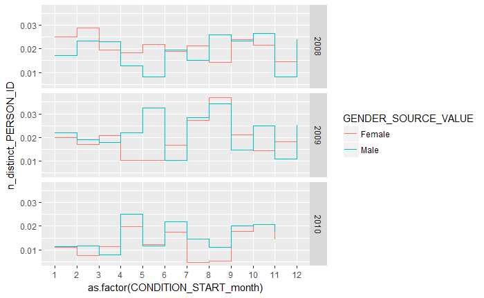

```r
g+geom_step()
```

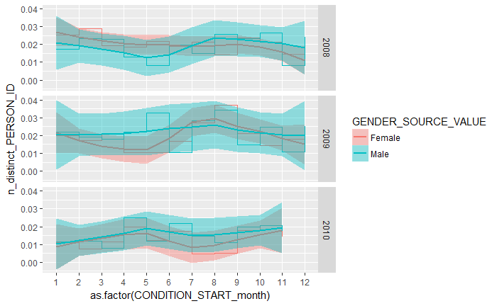

```r
g+geom_step()+geom_smooth(method = "loess")
```

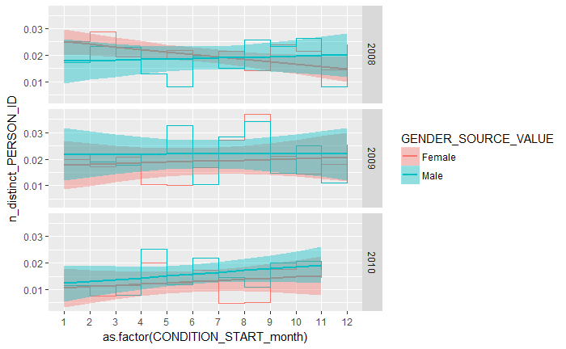

```r
g+geom_step()+geom_smooth(method = "lm")
```

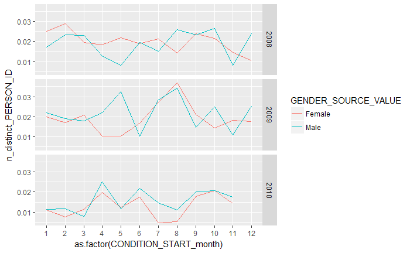

```r
g+geom_line()
```

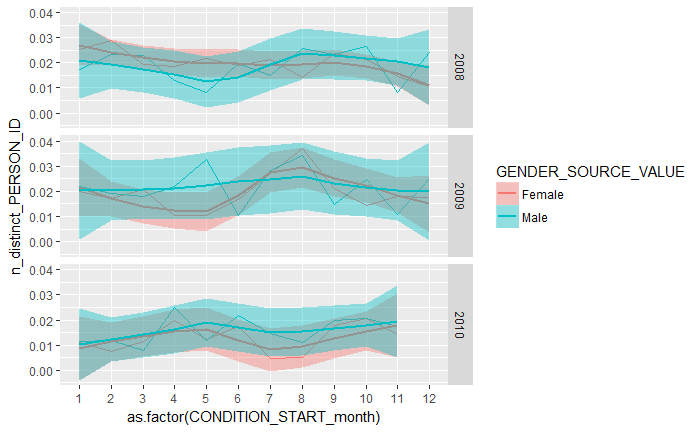

```r
g+geom_line()+geom_smooth(method = "loess")
```

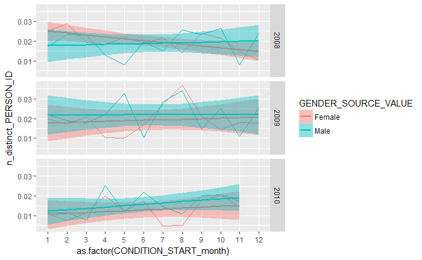

```r
g+geom_line()+geom_smooth(method = "lm")
```

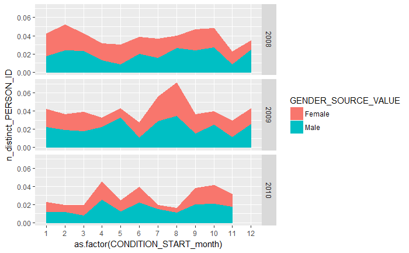

```r
g+geom_area()
```

```r
#@ total & MDD & pMDD (n_distinct_PERSON_ID, 1-year period prevalence/proportion, by state) ------
tblTotal = sqlQuery(channel, paste("
select year(convert(datetime, CONDITION_START_DATE, 112)) as CONDITION_START_year
    , STATE
    , count(*) as nrow
    , count(distinct CONDITION_OCCURRENCE_ID) as n_distinct_CONDITION_OCCURRENCE_ID
    , count(distinct CONDITION_OCCURRENCE.VISIT_OCCURRENCE_ID) as n_distinct_VISIT_OCCURRENCE_ID
    , count(distinct CONDITION_OCCURRENCE.PERSON_ID) as n_distinct_PERSON_ID
from (
    CONDITION_OCCURRENCE
    left join VISIT_OCCURRENCE
    on CONDITION_OCCURRENCE.VISIT_OCCURRENCE_ID = VISIT_OCCURRENCE.VISIT_OCCURRENCE_ID
    left join PERSON
    on VISIT_OCCURRENCE.PERSON_ID = PERSON.PERSON_ID
    left join LOCATION
    on PERSON.LOCATION_ID = LOCATION.LOCATION_ID
)
group by year(convert(datetime, CONDITION_START_DATE, 112)), STATE
order by year(convert(datetime, CONDITION_START_DATE, 112)), STATE
;"))
tblTotal
```

|  | CONDITION_START_year | STATE | nrow | n_distinct_CONDITION_OCCURRENCE_ID | n_distinct_VISIT_OCCURRENCE_ID | n_distinct_PERSON_ID |
| --- | --- | --- | --- | --- | --- | --- |
| 1 | 2008 |  | 303 | 303 | 94 | 5 |
| 2 | 2008 | AK | 25 | 25 | 6 | 1 |
| 3 | 2008 | AL | 975 | 975 | 241 | 10 |
| 4 | 2008 | AR | 911 | 911 | 243 | 12 |
| 5 | 2008 | AZ | 718 | 718 | 202 | 8 |
| 6 | 2008 | CA | 5234 | 5234 | 1446 | 72 |
| 7 | 2008 | CO | 565 | 565 | 159 | 9 |
| 8 | 2008 | CT | 660 | 660 | 173 | 6 |
| 9 | 2008 | DC | 21 | 21 | 7 | 1 |
| 10 | 2008 | DE | 37 | 37 | 10 | 1 |

[output cut: 146 more lines]

```r
tblMDD = sqlQuery(channel, paste("
select year(convert(datetime, CONDITION_START_DATE, 112)) as CONDITION_START_year
    , STATE
    , count(*) as nrow
    , count(distinct CONDITION_OCCURRENCE_ID) as n_distinct_CONDITION_OCCURRENCE_ID
    , count(distinct CONDITION_OCCURRENCE.VISIT_OCCURRENCE_ID) as n_distinct_VISIT_OCCURRENCE_ID
    , count(distinct CONDITION_OCCURRENCE.PERSON_ID) as n_distinct_PERSON_ID
from (
    CONDITION_OCCURRENCE
    left join VISIT_OCCURRENCE
    on CONDITION_OCCURRENCE.VISIT_OCCURRENCE_ID = VISIT_OCCURRENCE.VISIT_OCCURRENCE_ID
    left join PERSON
    on VISIT_OCCURRENCE.PERSON_ID = PERSON.PERSON_ID
    left join LOCATION
    on PERSON.LOCATION_ID = LOCATION.LOCATION_ID
)
where (CONDITION_SOURCE_VALUE like '2962%'
    or CONDITION_SOURCE_VALUE like '2963%'
)
group by year(convert(datetime, CONDITION_START_DATE, 112)), STATE
order by year(convert(datetime, CONDITION_START_DATE, 112)), STATE
;"))
tblMDD = full_join(select(tblTotal, -nrow, -n_distinct_CONDITION_OCCURRENCE_ID, -n_distinct_VISIT_OCCURRENCE_ID, -n_distinct_PERSON_ID), tblMDD)
```

```
Column `STATE` joining factors with different levels, coercing to character vector
```

```r
tblMDD
```

| CONDITION_START_year | STATE | nrow | n_distinct_CONDITION_OCCURRENCE_ID | n_distinct_VISIT_OCCURRENCE_ID | n_distinct_PERSON_ID |
| --- | --- | --- | --- | --- | --- |
| 2008 |  | NA | NA | NA | NA |
| 2008 | AK | NA | NA | NA | NA |
| 2008 | AL | NA | NA | NA | NA |
| 2008 | AR | 1 | 1 | 1 | 1 |
| 2008 | AZ | 5 | 5 | 1 | 1 |
| 2008 | CA | 40 | 40 | 18 | 8 |
| 2008 | CO | 1 | 1 | 1 | 1 |
| 2008 | CT | NA | NA | NA | NA |
| 2008 | DC | NA | NA | NA | NA |
| 2008 | DE | NA | NA | NA | NA |

[output cut: 146 more lines]

```r
tblMDDp = tblMDD; tblMDDp[,c("nrow", "n_distinct_CONDITION_OCCURRENCE_ID", "n_distinct_VISIT_OCCURRENCE_ID", "n_distinct_PERSON_ID")] = tblMDD[,c("nrow", "n_distinct_CONDITION_OCCURRENCE_ID", "n_distinct_VISIT_OCCURRENCE_ID", "n_distinct_PERSON_ID")]/tblTotal[,c("nrow", "n_distinct_CONDITION_OCCURRENCE_ID", "n_distinct_VISIT_OCCURRENCE_ID", "n_distinct_PERSON_ID")]
tblMDDp
```

| CONDITION_START_year | STATE | nrow | n_distinct_CONDITION_OCCURRENCE_ID | n_distinct_VISIT_OCCURRENCE_ID | n_distinct_PERSON_ID |
| --- | --- | --- | --- | --- | --- |
| 2008 |  | NA | NA | NA | NA |
| 2008 | AK | NA | NA | NA | NA |
| 2008 | AL | NA | NA | NA | NA |
| 2008 | AR | 0.0010976948 | 0.0010976948 | 0.004115226 | 0.08333333 |
| 2008 | AZ | 0.0069637883 | 0.0069637883 | 0.004950495 | 0.12500000 |
| 2008 | CA | 0.0076423386 | 0.0076423386 | 0.012448133 | 0.11111111 |
| 2008 | CO | 0.0017699115 | 0.0017699115 | 0.006289308 | 0.11111111 |
| 2008 | CT | NA | NA | NA | NA |
| 2008 | DC | NA | NA | NA | NA |
| 2008 | DE | NA | NA | NA | NA |

[output cut: 146 more lines]

```r
tblMDDp %>% full_join(., tibble(state.abb, state.name, state.name.tolower = tolower(state.name)), by = c("STATE" = "state.abb"))
```

| CONDITION_START_year | STATE | nrow | n_distinct_CONDITION_OCCURRENCE_ID | n_distinct_VISIT_OCCURRENCE_ID | n_distinct_PERSON_ID | state.name | state.name.tolower |
| --- | --- | --- | --- | --- | --- | --- | --- |
| 2008 |  | NA | NA | NA | NA | NA | NA |
| 2008 | AK | NA | NA | NA | NA | Alaska | alaska |
| 2008 | AL | NA | NA | NA | NA | Alabama | alabama |
| 2008 | AR | 0.0010976948 | 0.0010976948 | 0.004115226 | 0.08333333 | Arkansas | arkansas |
| 2008 | AZ | 0.0069637883 | 0.0069637883 | 0.004950495 | 0.12500000 | Arizona | arizona |
| 2008 | CA | 0.0076423386 | 0.0076423386 | 0.012448133 | 0.11111111 | California | california |
| 2008 | CO | 0.0017699115 | 0.0017699115 | 0.006289308 | 0.11111111 | Colorado | colorado |
| 2008 | CT | NA | NA | NA | NA | Connecticut | connecticut |
| 2008 | DC | NA | NA | NA | NA | NA | NA |
| 2008 | DE | NA | NA | NA | NA | Delaware | delaware |

[output cut: 146 more lines]

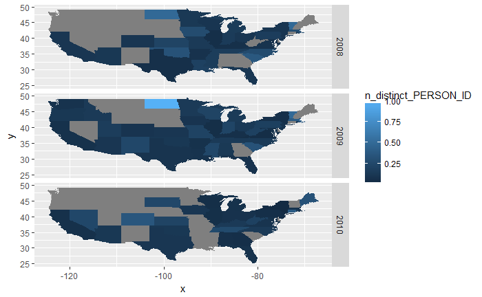

```r
library(maps)
map = map_data("state")
g = tblMDDp %>% full_join(., tibble(state.abb, state.name, state.name.tolower = tolower(state.name)), by = c("STATE" = "state.abb")) %>%
    ggplot(aes(fill = n_distinct_PERSON_ID)) +
    facet_grid(CONDITION_START_year~.)
g+geom_map(aes(map_id = state.name.tolower), map = map)+expand_limits(x=map$long, y=map$lat)
```

```r
detach("package:maps", unload=TRUE)
```

```r
#@ CMS_SynPUF_CDMv5_YZ.json -----
library(jsonlite)
CMS_SynPUF_CDMv5_YZ.json = fromJSON(url("https://raw.githubusercontent.com/mkim0710/tidystat/master/data/CMS_SynPUF_CDMv5_YZ.json"))
CMS_SynPUF_CDMv5_YZ.json %>% length
```

```
[1] 1000
```

```r
CMS_SynPUF_CDMv5_YZ.json[1000] %>% str
```

```
List of 1
 $ 999:List of 5
  ..$ DOB : int 1940
  ..$ appt:List of 7
  .. ..$ 20090501:List of 5
  .. .. ..$ actualdate: chr "20090501"
  .. .. ..$ diag      : chr [1:2] "462" "46421"
  .. .. ..$ drug      : list()
  .. .. ..$ proc      : chr "71020"
  .. .. ..$ type      : chr "887623388569362"
  .. ..$ 20090503:List of 5
  .. .. ..$ actualdate: chr "20090503"
  .. .. ..$ diag      : chr [1:3] "1731" "1731" "2329"
  .. .. ..$ drug      : list()
  .. .. ..$ proc      : chr [1:2] "73130" "88305"
  .. .. ..$ type      : chr "887683385170808"
  .. ..$ 20090607:List of 5
  .. .. ..$ actualdate: chr "20090607"
  .. .. ..$ diag      : chr [1:4] "1101" "1101" "1171" "7098"
  .. .. ..$ drug      : list()
  .. .. ..$ proc      : chr [1:2] "99212" "99212"
  .. .. ..$ type      : chr "887733386054944"
  .. ..$ 20090724:List of 5
  .. .. ..$ actualdate: chr "20090724"
  .. .. ..$ diag      : chr "4270"
  .. .. ..$ drug      : list()
  .. .. ..$ proc      : chr "36415"
  .. .. ..$ type      : chr "542122281130114"
  .. ..$ 20100207:List of 5
  .. .. ..$ actualdate: chr "20100207"
  .. .. ..$ diag      : chr [1:2] "3540" "3569"
  .. .. ..$ drug      : list()
  .. .. ..$ proc      : chr "99222"
  .. .. ..$ type      : chr "887713388554440"
  .. ..$ 20100410:List of 5
  .. .. ..$ actualdate: chr "20100410"
  .. .. ..$ diag      : chr [1:4] "4011" "73300" "73301" "73301"
  .. .. ..$ drug      : list()
  .. .. ..$ proc      : chr "77080"
  .. .. ..$ type      : chr "887473385353685"
  .. ..$ 20100905:List of 5
  .. .. ..$ actualdate: chr "20100905"
  .. .. ..$ diag      : chr [1:2] "7237" "72402"
  .. .. ..$ drug      : list()
  .. .. ..$ proc      : chr "62311"
  .. .. ..$ type      : chr "887163385548265"
  ..$ lab :List of 1
  .. ..$ 20100207:List of 1
  .. .. ..$ Audiogram abnormal: chr "255"
  ..$ race: chr "White"
  ..$ sex : chr "Male"
```

```r
#@ CMS_SynPUF_CDMv5_YZ.json.map_df = CMS_SynPUF_CDMv5_YZ.json %>% purrr::map_df(function(ls) { ----
CMS_SynPUF_CDMv5_YZ.json.map_df = CMS_SynPUF_CDMv5_YZ.json %>% purrr::map_df(function(ls) {
    ls %>% purrr::map(function(x) {
        if (is.list(x))
            x = length(x)
        if (length(x) > 1)
            x = length(x)
        x
    })
})
CMS_SynPUF_CDMv5_YZ.json.map_df
```

| DOB | appt | lab | race | sex |
| --- | --- | --- | --- | --- |
| 1932 | 65 | 3 | White | Male |
| 1957 | 8 | 1 | Others | Female |
| 1942 | 2 | 1 | White | Female |
| 1939 | 15 | 1 | White | Female |
| 1928 | 0 | 0 | White | Female |
| 1935 | 2 | 0 | White | Female |
| 1943 | 2 | 0 | White | Female |
| 1924 | 1 | 0 | White | Male |
| 1939 | 22 | 0 | White | Female |
| 1935 | 108 | 6 | White | Female |

[output cut: 990 more lines]

```r
g = CMS_SynPUF_CDMv5_YZ.json.map_df %>%
    ggplot(aes(x = sex, y = appt, color = sex))
```

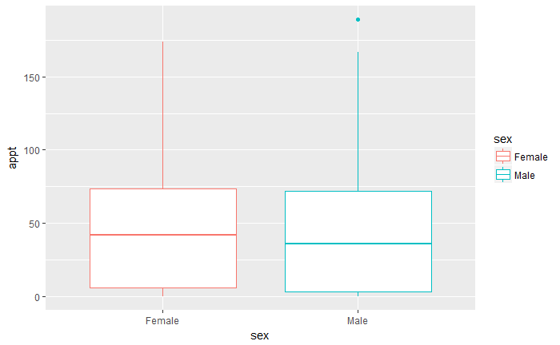

```r
g+geom_boxplot()
```

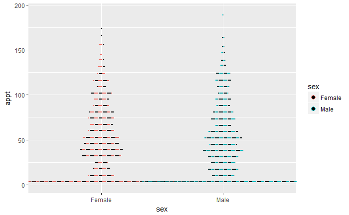

```r
g+geom_dotplot(binaxis = "y", stackdir = "center", dotsize = 1/5)
```

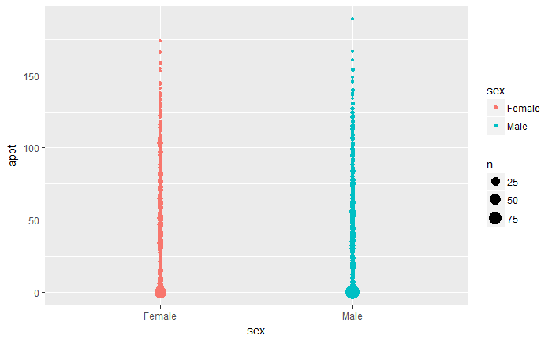

```r
g+geom_count()
```

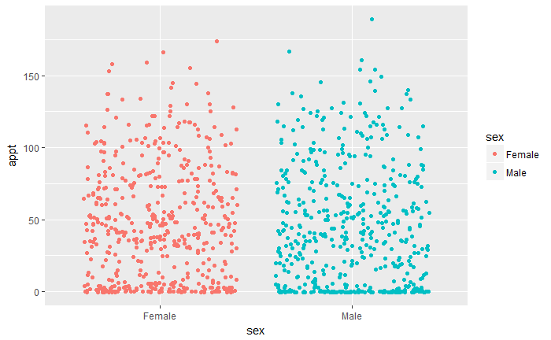

```r
g+geom_jitter()
```

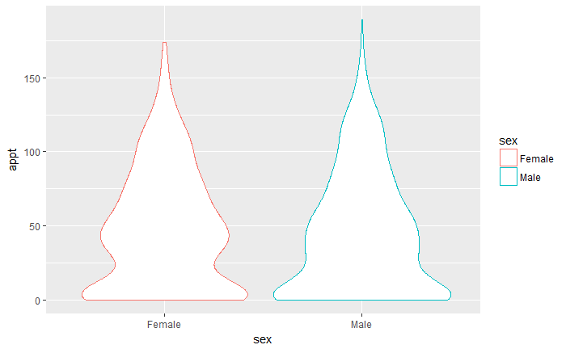

```r
g+geom_violin()
```

# Acknowledgements

The CMS 2008-2010 Data Entrepreneurs’ Synthetic Public Use File (DE-SynPUF) is provided by U.S. Centers for Medicare & Medicaid Services.

https://www.cms.gov/Research-Statistics-Data-and-Systems/Downloadable-Public-Use-Files/SynPUFs/DE_Syn_PUF.html

The Observational Medical Outcomes Partnership (OMOP) Common Data Model (CDM) Version 5 is provided by Observational Health Data Sciences and Informatics (OHDSI) community.

https://github.com/OHDSI/CommonDataModel

The 1000 person data set from the CMS 2008-2010 Data Entrepreneurs’ Synthetic Public Use File (DE-SynPUF) converted it to the OMOP Common Data Model Version 5 format was provided by LTS Computing LLC.

http://www.ltscomputingllc.com/downloads/

The 1000 person CMS_SynPUF_CDMv5 was loaded into MS SQL server in the Weill Cornell Architecture for Research Computing in Health (ARCH) by Evan Scholle, in the Information Technologies & Services, Weill Cornell Medicine.

The 1000 person CMS_SynPUF_CDMv5 transformed into JSON format was provided by Dr. Yiye Zhang in the Division of Health Informatics, Department of Healthcare Policy and Research, Weill Medical College of Cornell University.